Vamsi Gudipati

Portfolio · Convolutional networks on flow fields · October 2026

# One U-Net, two questions: sharpening turbulent fields in space, and why it cannot step them in time

The same 1.9-million-parameter network, trained the same way on the same 5,777 planes of a turbulent channel flow. Asked to put back what a four-times coarser grid lost, it beats bicubic upscaling on every test plane and restores half of the missing small-scale energy. Asked to predict the next snapshot, it beats persistence by a wide margin and the mean velocity profile by 3 %, because at ten time units apart the next fluctuation is uncorrelated with the current one. Fed its own output, every model, including one trained elsewhere, falls behind the mean profile from the second step.

**Vamsi Gudipati** Super-resolution · Time stepping · TFRecord data pipelines · Reference-first evaluation [Repository](https://github.com/vamsigudipati/unet-turbulent-fields)

0.365

U-Net MSE as a fraction of bicubic upscaling's, better on all 868 test planes

0.51 vs 0.20

small-scale energy restored, U-Net against bicubic

0.2078 ± 0.0006

one-step MAE (3 seeds) against 0.2146 for the mean profile alone

−0.034

correlation of consecutive fluctuations: the next field is nearly independent

step 2

where every rollout, mine or pretrained, falls behind the mean profile

## Objective

A direct numerical simulation of turbulence resolves every scale of the flow and leaves behind a large collection of fields. Two things people want a neural network to do with such fields come up again and again: sharpen a coarse field into a fine one, and step a field forward in time. I put one convolutional network, a four-level U-Net with 1.94 million parameters, to both jobs on the same data, 5,777 planes of the streamwise velocity from a turbulent channel flow, and measured each result against the answer that costs nothing. The work is four stages, each a notebook:

1. **Stage 1 — U-Net super-resolution of turbulent channel-flow fields.** Every plane is coarsened by a factor of 4, interpolated back, and the U-Net learns to recover the original; five experiments vary the factor, the width, the target and the loss.
2. **Stage 2 — Temporal pairs as TFRecords.** The planes become pairs of consecutive snapshots, split in time, scaled with training statistics and written as sharded TFRecord files, so that the next stage can train without holding the data in memory.
3. **Stage 3 — U-Net temporal evolution from TFRecords.** The same U-Net, streamed from those files, learns u(t) → u(t + 1); five experiments vary the stride, the width, the target, the rollout length and the input pipeline.
4. **Stage 4 — Baselines and rollout.** Trains nothing. It scores the models of Stages 1 and 3 against nearest-neighbour, bilinear and bicubic upscaling, and against persistence and the mean velocity profile, at one step and over rollouts as long as the data allow.

Every training of fifteen minutes or less is repeated with three seeds, so a difference is called an effect only when it is larger than the spread between repeats. The two training notebooks also came with a model each, trained elsewhere; Stage 4 scores those as an extra row, labelled as pretrained.

## Problem statement

The planes are y–x slices (wall-normal by streamwise, 201 × 384 points) of u, one HDF5 file each, at 60 spanwise positions and snapshots 30000 to 30106. In space the question is whether a network can put back what a four-times coarser grid cannot carry. In time it is whether the field now determines the field one snapshot later well enough to learn. The network, its size and every training setting are the same for both; only the meaning of input and output changes.

[figure not shown]

**What stays fixed is the flow, the planes and the network; what changes is the question.** Blue: the physical source; teal: the two datasets; violet: the shared network; orange: the headline results on the 201 physical rows of each plane, in normalised units.

[figure not shown]

**How the stages connect.** One file link (the record shards, their metadata and the scaling statistics, from Stage 2 to Stage 3) and two code links (the plane reader re-implemented in Stage 2; the same U-Net code in Stages 1 and 3). Stage 4 reads the planes and the saved models.

The references matter as much as the models. For super-resolution a careful engineer would try bicubic upscaling before any network; for time stepping, persistence (the next field equals the current one) and, less obviously, the mean velocity profile, which ignores the current field entirely. A model that does not beat those has learned nothing a lookup table would not give.

## Method

### One U-Net, two roles

A U-Net is an encoder–decoder: four levels of two 3 × 3 convolutions, each level halving the field with max pooling and doubling the filters (16, 32, 64, 128, then a 256-filter bottleneck at 13 × 24), and the mirror image going back up with transposed convolutions. Skip connections copy each encoder level's output next to the decoder level of the same size, so fine detail that the pooling discarded is available again when the field is rebuilt. A final 1 × 1 convolution gives one output channel the size of the input. The planes are edge-padded from 201 to 208 rows so that four halvings divide evenly.

[figure not shown]

**The four-level U-Net of Stage 1, 1,940,817 parameters.** Each encoder level: two 3 × 3 convolutions and a 2 × 2 max pool; each decoder level: a transposed convolution, concatenation with the skip, two convolutions. The same code builds the Stage 3 network.

[figure not shown]

**The same network in space and in time.** Left: the input is the coarse field interpolated back to full size, the target is the fine field of the same plane. Right: the input is the field at snapshot t, the target the field at t + 1. The loss is the mean squared error in both.

### Data from the planes, two ways

Stage 1 holds everything in memory: all 5,777 planes padded, coarsened by area averaging and interpolated back, split 70/15/15 in file order (4,043 training, 866 validation, 868 test planes), and scaled with the mean and standard deviation of the training targets only. Stage 2 builds the second dataset for the disk: each snapshot paired with the next one of the same plane (5,667 pairs), the first 85 % of each plane's pairs for training and the rest for validation (4,810 and 857), one mean and one standard deviation from the training fields, and every pair serialised into one of ten TFRecord shards. Stage 3 streams those shards through a `tf.data` pipeline that parses, normalises, shuffles and batches eight pairs at a time, with one pair in memory per record.

[figure not shown]

**What one record holds.** Two padded fields as bytes, their shape, the snapshot numbers and the plane label, 639,160 bytes each; the metadata JSON and the statistics file are the contract between Stage 2 and Stage 3.

### References and how the error is read

- **Space:** nearest-neighbour, bilinear (the Stage 1 input) and bicubic upscaling of the same coarse field, scored on the 868 test planes over the 201 physical rows. Besides the mean squared error, the streamwise energy spectrum tells which scales come back: the coarse grid carries wavenumbers up to 48, the band 49 to 128 is what has to be re-created, and the reference planes hold nothing above 128.
- **Time:** persistence and the mean profile U(y), averaged over x and over the 50 complete planes of the training period, scored on the 857 validation pairs; then rollouts, the model fed its own output, from snapshot 30090 for 16 steps (every target in the validation period) and from 30000 for 106 steps, on all 50 complete planes.
- **Seeds 0, 1, 2** for every training that fits in fifteen minutes: all experiment trainings of both notebooks and the Stage 3 main training. The Stage 1 main training is one run.

## Implementation

What was run, and with what.

[output not shown]

## Results 1 — Putting the small scales back (Stage 1)

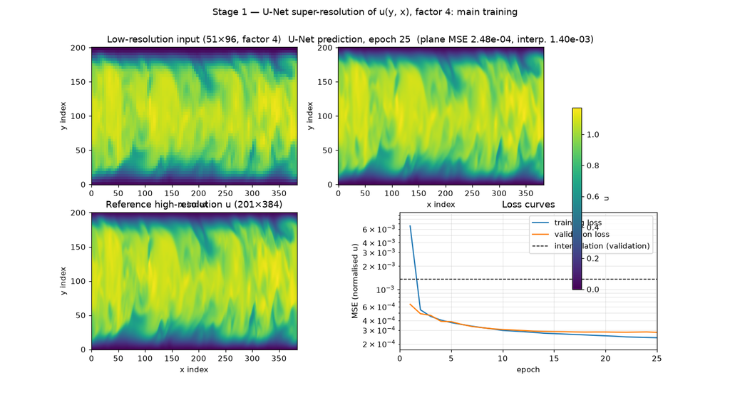

The notebook's own numbers, averaged over the 208 padded rows; the main training is one run.

| Quantity (normalised u) | Value |
| --- | --- |
| Interpolation (bilinear), test MSE | 1.318e-3 |
| U-Net, test MSE, 25 epochs | 2.690e-4 |
| U-Net, test MAE | 0.00948 |
| Gradient error, U-Net / interpolation | 3.16e-4 / 6.95e-4 |
| Earlier 50-epoch run, test MSE | 2.583e-4 |

The U-Net leaves about a fifth of the error of the bilinear interpolation it starts from, and about half the error on gradients. The 25-epoch training lands within 4 % of the earlier 50-epoch run, and the learning curve below shows why: the validation loss is nearly flat after epoch 20.

The example plane the notebook shows is a training plane, and the errors it prints include the seven padded rows near the wall, where the error is close to zero. Over the 201 physical rows the main model's MSE is 2.78e-4 rather than 2.690e-4; every comparison in Stage 4 uses the physical rows.

[figure not shown]

**Validation MSE per epoch, this run against the earlier 50-epoch run.** Both start from the same interpolation error; this run stops at 25 epochs with 2.863e-4, the earlier run reached 2.756e-4 at 50 and 2.764e-4 at 25.

### What the experiments say, with three seeds

[figure not shown]

**Seven variants at the reduced budget, three seeds each.** Test MSE, logarithmic scale; the grey marks are the interpolation error at each factor. The main model, one run at the full budget, is the dashed line.

Interpolation at factor 2 / 4 / 8: 1.719e-4 / 1.318e-3 / 7.044e-3.

| Variant (reduced budget) | Test MSE, 3 seeds |
| --- | --- |
| Factor 2 | 1.106e-4 ± 3.9e-5 |
| Factor 4 (base 16, direct) | 4.385e-4 ± 1.6e-5 |
| Factor 8 | 2.423e-3 ± 3.1e-5 |
| Base 8 filters | 7.09e-4 ± 1.2e-4 |
| Base 32 filters | 3.34e-4 ± 2.5e-5 |
| Residual target | 3.65e-4 ± 3.9e-5 |
| Gradient loss | 4.21e-4 ± 3.3e-5 |

**Width is an effect:** 8, 16 and 32 base filters give 7.09e-4, 4.39e-4 and 3.34e-4, each step larger than the spread. **The factor is the difficulty:** at factors 4 and 8 the U-Net keeps about a third of interpolation's error (0.33 ± 0.01 and 0.34 ± 0.004); at factor 2 the ratio is 0.64 ± 0.22, the widest spread of any variant, because the interpolation is already good and the small-scale remainder is hard to pin down. The earlier single run had read that ratio as 0.48 and concluded that factor 2 was the hardest to improve; three seeds say the number is one draw.

**The gradient loss does what it is for:** at an equal field error it lowers the gradient error from 6.36e-4 ± 5.2e-5 to 4.96e-4 ± 3.9e-5.

[figure not shown]

**U-Net MSE as a fraction of interpolation's, by factor.** Teal: seeds 0, 1 and 2 with their mean and spread; the orange square is the earlier single run. The factor-2 ratio moves from 0.48 to 0.90 between runs with the same seed; the factor-4 and factor-8 ratios do not move.

**Residual learning did not survive a second execution.** In this run, predicting the correction to the interpolated field instead of the field itself gave 3.65e-4 ± 3.9e-5 against 4.39e-4 ± 1.6e-5, a gain larger than the spread. When I executed the repository's notebooks again in their own layout, the two came out at 3.93e-4 ± 1.6e-5 and 4.16e-4 ± 3.9e-5, within each other's spread. I report it as a difference that two executions do not agree on, not as a finding.

## Results 2 — Pairs on disk, checked byte for byte (Stage 2)

[figure not shown]

**From 5,777 files to ten shards.** Scan and sort the file names, pair t with t + 1 within each plane, split each plane in time, stream the statistics from training fields only, then serialise every pair, one in memory at a time, and read the first record back against its HDF5 file.

Every number identical to the earlier run; the ten shards are byte-identical (SHA-1) to the ones delivered with the data.

| Quantity | Value |
| --- | --- |
| Pairs (t, t + 1) | 5,667 |
| Training / validation pairs | 4,810 / 857 |
| Training mean / std of u | 0.7847 / 0.3411 |
| Record size | 639,160 bytes |
| Shards | 8 training + 2 validation, 3.62 GB |
| Run time | 45 s |

The pipeline does what it promises: content exact, statistics from training data only, memory bounded. The point of writing 3.6 GB of records for data that fit in memory is the habit for the data that will not.

[figure not shown]

**Where the three stages cut the same snapshots.** Top: the stored time of each snapshot and the clock reset. Stage 1 splits planes in file order; Stages 2 and 3 split each plane's pairs in time; Stage 4 rolls out from 30090 (validation only) and from 30000.

## Results 3 — Stepping the field forward (Stage 3)

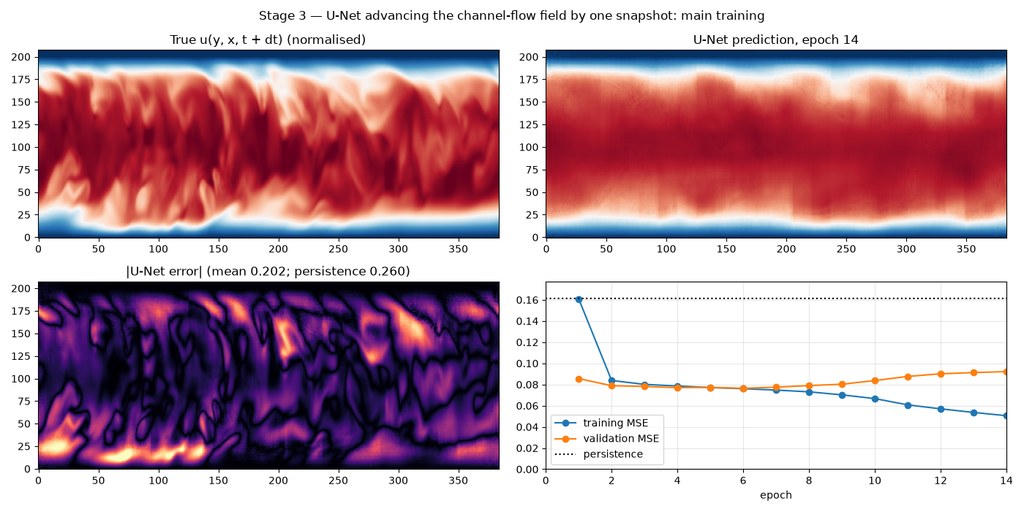

[figure not shown]

**The validation loss stops falling after epoch 6 while the training loss keeps falling.** Violet: validation MSE; grey: training MSE; orange: persistence on the same stream; the vertical line marks the epoch whose weights were kept. Seed 0.

The stored metadata of the saved model records the last epoch's loss (0.0902), not the restored best (0.0757).

| Quantity (normalised u, 208 rows) | 3 seeds |
| --- | --- |
| Validation MSE | 0.0763 ± 0.0008 |
| Validation MAE | 0.2013 ± 0.0005 |
| Persistence MSE / MAE | 0.1612 / 0.2896 |
| Best epoch / stop | 5–6 / 13–14 |
| Training time per seed | 15 to 17 min |

At one step the U-Net is far better than persistence, and the three seeds agree to the third digit. The network starts to memorise after six epochs: the validation loss turns up while the training loss keeps going down, and the early-stopping rule keeps the epoch-6 weights.

### Experiments: nothing moves the one-step error

[figure not shown]

**Seven variants, three seeds each, validation MAE.** Width, residual target and stride change the error by less than the spread, or by the amount persistence itself changes; the dark bars are persistence on the same pairs.

Eight, 16 and 32 base filters give 0.2081 ± 0.0029, 0.2046 ± 0.0014 and 0.2060 ± 0.0042: no reliable difference, where in Stage 1 width was a clear effect. Residual and direct targets tie (0.2044 ± 0.0019 against 0.2046 ± 0.0014). A stride of 1, 2 or 5 snapshots leaves the U-Net at 0.72 to 0.74 of persistence's error throughout. The same knobs that mattered in space do nothing in time, which is the first sign that the data, not the network, decide this task.

### Fed its own output

[figure not shown]

**The notebook's five-step rollout from one training-period plane.** MAE of u in physical units; violet: the three seed models; orange: persistence from the same start field.

From the notebook's start field the U-Net's error rises from 0.065 to about 0.10 within four steps while persistence stays between 0.087 and 0.098; the first step at which the U-Net is worse than persistence is 4, 4 and 6 for the three seeds. Over 30 steps every model leaves the data: at step 30 the three main models reach 0.88, 52.6 and 833.7 against 0.114 for persistence, for a velocity whose range is −0.03 to 1.29.

Those step-30 numbers vary by three orders of magnitude between seeds and, in the second execution, by four more (14,142 for seed 0). A single rollout number says little; what is repeatable is that the learned map is unstable when applied to itself.

[figure not shown]

**Thirty steps, nine models, logarithmic scale.** Main training, direct and residual targets at the reduced budget, three seeds each, against persistence. The residual models diverge fastest.

## Results 4 — Against the answer that costs nothing (Stage 4)

### Space: better than bicubic on every plane

[figure not shown]

**Three views of the same 868 test planes.** Left: MSE per plane, bar the mean, line the 5th to 95th percentile. Middle: the streamwise energy spectrum of the reference planes, with the band the coarse grid cannot carry shaded and the empty band above k = 128 pale. Right: energy kept at each wavenumber as a fraction of the reference; the U-Nets hold about half of it where bicubic holds a fifth.

Normalised units, 201 physical rows. Bicubic keeps 0.954 of the energy at k ≤ 48 and the U-Net 0.999.

| Method | MSE per plane | Relative to bicubic | Planes better than bicubic | Energy kept, k = 49–128 |
| --- | --- | --- | --- | --- |
| Nearest-neighbour | 5.44e-3 | 7.14 | 0 % | 3.62 (spurious, from block edges) |
| Bilinear (the Stage 1 input) | 1.36e-3 | 1.79 | 0 % | 0.20 |
| Bicubic | 7.62e-4 | 1.00 | — | 0.20 |
| U-Net, main training (one run) | 2.78e-4 | 0.365 | 100 % | 0.51 |
| U-Net, pretrained model, trained elsewhere (50 epochs) | 2.70e-4 | 0.354 | 100 % | 0.51 |
| U-Net, reduced budget (3 seeds) | 4.53e-4 ± 1.7e-5 | 0.594 ± 0.022 | 100 % | 0.34 ± 0.007 |

### Time: the gain is the mean flow

[figure not shown]

**How much the current field says about the next ones.** Correlation of the fluctuation u − U(y) with the start field, mean over 50 planes: −0.034 one snapshot ahead, 0.037 sixteen ahead. At this spacing, consecutive fields are essentially unrelated.

201 physical rows, normalised units. Every model and the mean profile beat persistence on all 857 pairs.

| Reference or model | One-step MAE (857 pairs) |
| --- | --- |
| Persistence | 0.2997 |
| Mean profile U(y) | 0.2146 |
| U-Net, 3 seeds | 0.2078 ± 0.0006 |
| U-Net, pretrained model | 0.2089 |

Persistence pays for copying a fluctuation that has gone; the mean profile pays nothing for it; the U-Net has learned mostly to return the mean flow, plus 0.007 in MAE that may come from the current field. The notebook's claim that the U-Net improves on persistence is true. It is not evidence that the network follows the turbulence: 1.9 million parameters improve on a profile of 201 numbers by 3 %.

[figure not shown]

**One step, then rollouts on 50 planes.** Left: MAE per validation pair, bar the mean, line the 5th to 95th percentile. Middle: the clean 16-step rollout from snapshot 30090. Right: the 106-step rollout from 30000, both axes logarithmic. The marks on the rollout curves are the first step at which each model is worse than persistence.

Mean over the 50 complete planes.

| Rollout | Worse than the mean profile from | Worse than persistence from |
| --- | --- | --- |
| Clean, 16 steps from 30090 | step 2, every model | steps 8, 8 and 6 (seeds); 11 (pretrained) |
| Long, 106 steps from 30000 | step 2, every model | steps 5, 5 and 6 (seeds); 6 (pretrained) |

The spread of the predicted fields is 0.94 to 0.95 of the true one after one step and 1.2 to 19 times it after 16 steps.

| MAE at the last step | Seed 0 | Seed 1 | Seed 2 | Pretrained | Persistence | Mean profile |
| --- | --- | --- | --- | --- | --- | --- |
| Clean, step 16 | 0.40 | 0.99 | 9.7 | 0.33 | 0.29 | 0.22 |
| Long, step 106 | 4e5 | 3e14 | 3e19 | 5.2 | 0.31 | 0.22 |

Fed its own output, every model, mine and the one trained elsewhere, falls behind the mean profile from the second step. That the pretrained model fails the same way is the strongest evidence that the failure belongs to the task as posed, snapshots ten time units apart, and not to my training. The step at which a model falls behind persistence is not repeatable: 8, 8 and 6 in this execution, 6, 5 and beyond 16 in the second one. The loss to the mean profile from step 2 is the same in every model and every execution.

## Key observations

1. **The data decide, not the network.** With the network, its size and its training held fixed, the U-Net keeps a third of bicubic's error in space and cannot beat a 201-number profile by more than 3 % in time. In space the coarse field determines the large scales and the network learns the rest; in time the next fluctuation is uncorrelated with the current one (−0.034) and only the mean flow is learnable.
2. **Pick the reference before the model.** Bilinear, the notebook's own baseline, leaves twice the error of bicubic; persistence leaves 40 % more than the mean profile. 'Five times better than interpolation' and 'better than persistence' are both true statements that overstate what was learned.
3. **Look at the spectrum, not only the mean error.** Nearest-neighbour upscaling shows 3.6 times the reference energy at small scales, all of it spurious block edges; a mean error alone would not have said so. The U-Net restores half of the lost small-scale energy, bicubic a fifth.
4. **Settings that matter in space do nothing in time.** Width is an effect in Stage 1 (7.1e-4, 4.4e-4, 3.3e-4 for 8, 16, 32 filters) and none in Stage 3; residual learning helped in one execution of Stage 1 and not in the next, and never in Stage 3.
5. **One training is one draw.** The factor-2 ratio moved from 0.48 to 0.90 with the same seed between executions; rollout errors at step 30 range over seven orders of magnitude across nine trainings; the residual-learning gain appeared in one execution and vanished in the next. The numbers that survive are the ones I report as findings.
6. **A learned map applied to itself needs its own test.** The one-step error is stable to the third digit; the rollout diverges, and the spread of the predicted fields (1.2 to 19 times the true one after 16 steps) is the sign of it. The early-stop epoch, 5 or 6 of 50, shows the same thing from the other side: there is little to learn beyond the mean.

## Conclusion

What the stages do not establish: whether the temporal U-Net would follow the turbulence with snapshots closer in time, which needs other data; whether either network works on another flow, another Reynolds number, another velocity component or coarse data not made by its own averaging rule; and whether the main super-resolution result is typical, since it is one training, though the three reduced-budget seeds agree closely. The next steps are a dataset saved at a time step short enough for consecutive fields to be related, a test of the super-resolution model on a factor it was not trained on, and statistics of the rolled-out fields (profile, spread, spectrum) rather than their point-by-point error.

## Code, data and reproducibility

The four notebooks of the repository, each also exported as HTML with all outputs.

| Notebook | Stage |
| --- | --- |
| `01_unet_turbulent_superresolution.ipynb` | Stage 1 — U-Net super-resolution of turbulent channel-flow fields |
| `02_prepare_temporal_pairs_tfrecords.ipynb` | Stage 2 — Temporal pairs as TFRecords |
| `03_unet_temporal_evolution.ipynb` | Stage 3 — U-Net temporal evolution from TFRecords |
| `04_baselines_and_rollout.ipynb` | Stage 4 — Baselines and rollout |

[output not shown]